# (Ford GoBike System Data)

## by (Youssef Hussein Ahmed)

## Investigation Overview

- In this investigation, I wanted to look at the features that could be used to predict the duration of variable trips.
- The main focus was on the these 10 features:
  - start_time
  - end_time
  - start_station_latitude
  - start_station_longitude
  - end_station_latitude
  - end_station_longitude
  - user_type
  - member_birth_year
  - member_gender
  - bike_share_for_all_trip

### Dataset Overview

This data set includes information about individual rides made in a bike-sharing system covering the greater San Francisco Bay area.

## Distribution of Trips Durations

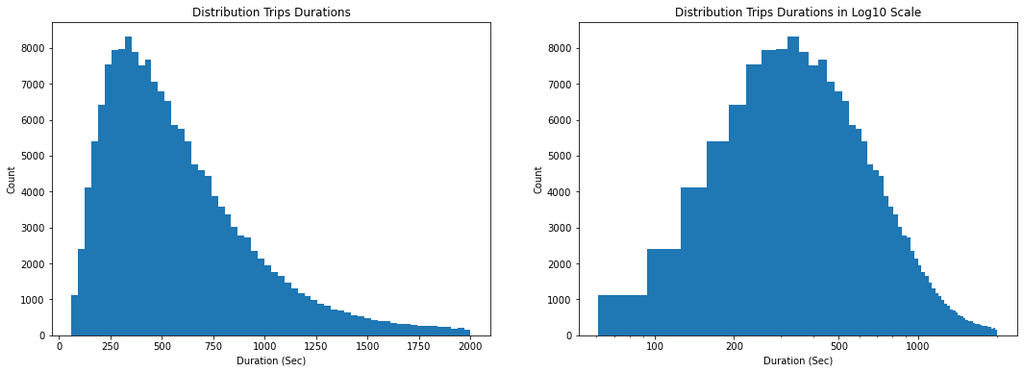

```python
plt.figure(figsize= [18, 6])
stp= (2e3- 60) / 60

plt.subplot(1, 2, 1)
plt.hist(feat_df.duration_sec, bins= np.arange(61, 2e3+stp, stp))
plt.title('Distribution Trips Durations')
plt.xlabel('Duration (Sec)')
plt.ylabel('Count')

# Log10 scale
plt.subplot(1, 2, 2)
plt.hist(feat_df.duration_sec, bins= np.arange(61, 2e3+stp, stp))
plt.xscale('log')

x_ticks= [100, 200, 500, 1000]
plt.xticks(x_ticks, x_ticks)
plt.title('Distribution Trips Durations in Log10 Scale')
plt.xlabel('Duration (Sec)')
plt.ylabel('Count');
```

- Duration is mostly centered on values that less than 2000 sec.
- Trips number increases starting from around 1000 trip to 8500 trip in duration values up to 400 sec but then starts to decrease to less than 1000 trip in duration values that under 1300 sec.
- Distribution in normal scale seemed to be a little right skewed but in log10 scale seemed to be normally distributed.

## Distribution of Start Time and End Time

- These variables has unfamiliar dtype (datetime64)..
- I treated them as ordinal variables with intervals of hours or days.
- By seprating each variable into 2 additional cols for ex: start_time can be seprated into:
  - **start_time** encoded into categorical variable with dayparts as categories.
  - **day** encoded into categorical variable with (Weekday, Weekend) as categories.

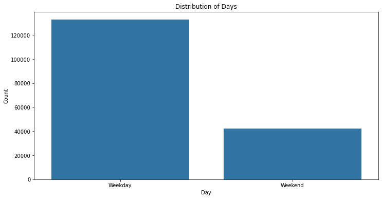

```python
plt.figure(figsize= [12, 6])

base_color = sb.color_palette()[0]
sb.countplot(data= feat_df, x= 'day', color= base_color)
plt.title('Distribution of Days')
plt.xlabel('Day')
plt.ylabel('Count');
```

- It seems the largest percentage of trips are made during weekdays rather than weekends.

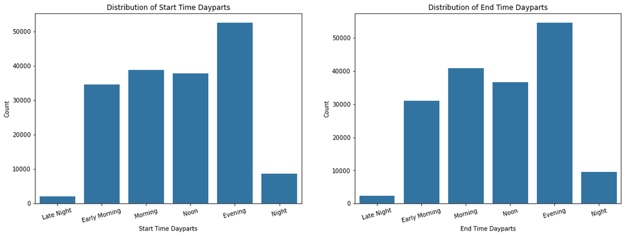

```python
plt.figure(figsize= [18, 6])

plt.subplot(1,2,1)
sb.countplot(data= feat_df, x= 'start_time', color= base_color, order= dayparts_type.categories)
plt.xticks(rotation= 15)
plt.title('Distribution of Start Time Dayparts')
plt.xlabel('Start Time Dayparts')
plt.ylabel('Count')

plt.subplot(1,2,2)
sb.countplot(data= feat_df, x= 'end_time', color= base_color, order= dayparts_type.categories)
plt.xticks(rotation= 15)
plt.title('Distribution of End Time Dayparts')
plt.xlabel('End Time Dayparts')
plt.ylabel('Count');
```

## Distribution of User Type

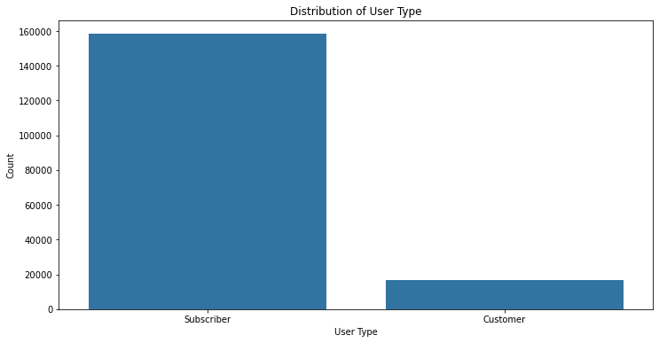

```python
plt.figure(figsize= [12, 6])

sb.countplot(data= feat_df, x= 'user_type', order= feat_df.user_type.value_counts().index, color= base_color)
plt.xlabel('User Type')
plt.ylabel('Count')
plt.title('Distribution of User Type');
```

- It seems the largest percentage of trips are by subscribers rather than customers.

## Distribution of Member Birth Year

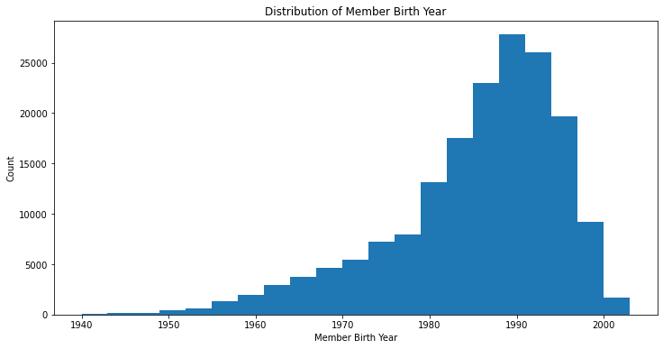

```python
plt.figure(figsize= [12,6])

plt.hist(feat_df.member_birth_year, bins= np.arange(1940, 2006, 3))
plt.xlabel('Member Birth Year')
plt.ylabel('Count')
plt.title('Distribution of Member Birth Year');
```

## Distribution of Member Gender

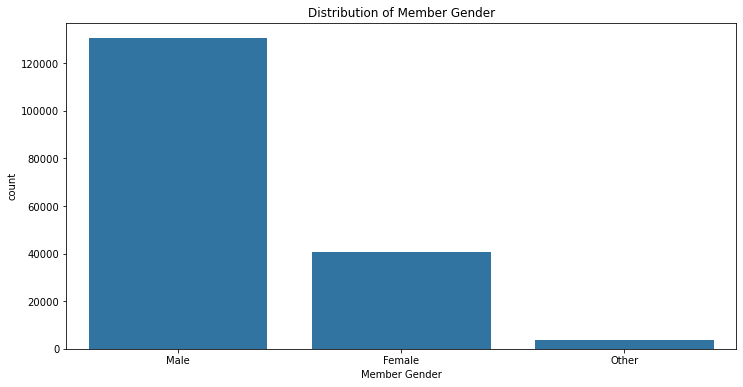

```python
plt.figure(figsize= [12,6])

sb.countplot(data= feat_df, x= 'member_gender', order= feat_df.member_gender.value_counts().index, color= base_color)
plt.xlabel('Member Gender')
plt.title('Distribution of Member Gender');
```

- It seems the largest percentage of trips are by males.